# Brown (1992) British names for American birds - similarity measures

Computes perceptual similarity (AVONET Euclidean distance), phylogenetic similarity (mean cophenetic distance over BirdTree posterior samples) and taxonomic similarity (Clements 1974 and 2023) for every pair of birds within each of the 26 arrays of Brown’s (1992) similarity judgement experiment (`brown_table3.csv`). It then ranks the candidates in each array by each measure and plots where the measures put the birds Brown’s subjects actually chose.

The measures replicate those in `preprocessing/Preprocessing.Rmd`, so that Brown’s subject judgements can be compared against the same similarity measures used elsewhere in this repository. Nothing outside `brown_britishnames/` is written to; the reference taxonomies under `preprocessing/data/` are read only.

The phylogenetic measure reads `nexus_brown.nex`, the BirdTree tree-pruner download covering Brown’s 99 birds that sits alongside this notebook - see the phylogenetic section below for how it was produced. If it is removed the notebook still runs and reports the other three measures.

A final section adds the plumage colour data the pipeline uses, as a measure on its own and combined with AVONET.

# Setup

```r
rm(list = ls())

library(tidyverse)
library(here)
library(rdist)
library(ape)
select <- dplyr::select

# The bootstraps below resample arrays at random
set.seed(302)
```

# Define Functions

`TaxSimCalc` is copied verbatim from `preprocessing/Preprocessing.Rmd` so that the taxonomic distances here are identical to those used for the language datasets. (The source is an .Rmd and so cannot be `source()`d.) `MinVal` is not needed - we want pairwise distances, not isolation measures.

```r
# This one calculates similarity based on matches and mismatches in a taxonomy. You just give it a dataframe and a list of the columns to compare. The columns should be Order, Family, Genus and Species if you're just comparing birds. Species should be the binomial species name (including both the genus and the species) because the second part of the species name on its own can match between totally unrelated species (e.g., Dromaius novaehollandiae & Larus novaehollandiae)

TaxSimCalc <- function(data, columns_to_compare) {

    # Function to take numbers and punctuation out of names - I had to add this because I have sometimes added numbers to the ends of species to make them unique in the datasets.
  clean <- function(str) {
    # Remove punctuation and numbers
    cleaned_str <- gsub("[[:punct:]0-9]", "", str)
    # Convert to lowercase for case-insensitive matching - probably not necessary but just in case
    tolower(cleaned_str)
  }

  data <- data %>% drop_na(columns_to_compare)

  # Create an empty matrix
  matrix <- matrix(0, nrow = nrow(data), ncol = nrow(data))

  # Calculate matches for taxa
  for (i in 1:(nrow(data) - 1)) {
    for (j in (i + 1):nrow(data)) {

      # Clean and preprocess strings for comparison
      cleaned_i <- clean(data[i, columns_to_compare])
      cleaned_j <- clean(data[j, columns_to_compare])

      # Count the number of matching values across columns
      matches <- sum(cleaned_i == cleaned_j)

      # Store the matches count in the matrix
      matrix[i, j] <- matches
      matrix[j, i] <- matches
    }

    # Make the diagonal terms all perfect matches
    matrix[i, i] <- length(columns_to_compare)
  }

  # Make it so that perfect match = 0 and perfect mismatch = how many steps up the taxonomic tree you have to get to before they are in the same taxon. (Which in the case of birds species would always be 4 because they're all in the same class - Aves)
  matrix <- length(columns_to_compare) - matrix

  # Convert the matrix to a data frame
  df <- as.data.frame(matrix)

  # Put the names back in
  colnames(df) <- data$CanonicalName
  df$Species1 <- data$CanonicalName

  # Create pairwise list
  list <- df %>%
    pivot_longer(cols = -contains("Species1"),
                 names_to = "Species2",
                 values_to = "Dist") %>%
    mutate(s1 = pmin(Species1, Species2),
           s2 = pmax(Species1, Species2)) %>%
    select(s1, s2, Dist) %>%
    distinct() %>%
    filter(s1 != s2) %>%
    rename(Species1 = s1,
           Species2 = s2) %>%
    mutate(ScaleDist = scale(Dist)[,1])

  return(list(matrix = df, pairs = list))
}
```

The functions below bootstrap the mean ranks reported later on. Two resampling schemes are used throughout, because they answer different questions and it is worth seeing both:

- **Over arrays** - draw 26 arrays with replacement, keeping every subject inside a drawn array. This asks how the measures would compare on *a different set of bird arrays*, treating Brown’s 26 stimulus sets as a sample. It is the conservative scheme, and the one that matches the scientific claim about naming in general.
- **Over subjects** - hold the 26 arrays fixed and resample each array’s 34 subject choices with replacement. This asks how the measures would compare if *different people* had judged these same pictures. It gives much tighter intervals, but says nothing about whether the result would hold on other birds.

Neither is the “right” one. Intervals from the subject scheme will be far narrower; that is a consequence of the easier question, not better evidence.

```r
# Resampling over ARRAYS. Takes a long data frame with columns array, Measure, Rank
# and w (the weight given to each row - 1 to weight every row equally, or the number
# of subjects to weight by votes) and returns a B x measures matrix of bootstrap
# replicates of the mean rank. Each replicate draws 26 arrays with replacement and
# recomputes the weighted mean from whichever arrays came up.

BootstrapMeanRankArrays <- function(ranks, B = 10000) {

  measure_levels <- levels(ranks$Measure)

  # Collapse to one row per array per measure first, so a replicate is just a sum
  # over the drawn arrays
  cells <- ranks %>%
    group_by(array, Measure) %>%
    summarise(S = sum(w * Rank), W = sum(w), .groups = "drop")

  to_matrix <- function(value_col) {
    cells %>%
      select(array, Measure, all_of(value_col)) %>%
      pivot_wider(names_from = Measure, values_from = all_of(value_col)) %>%
      arrange(array) %>%
      column_to_rownames("array") %>%
      as.matrix() %>%
      .[, measure_levels, drop = FALSE]
  }

  S <- to_matrix("S")
  W <- to_matrix("W")

  n_arrays <- nrow(S)
  draws <- matrix(NA_real_, nrow = B, ncol = length(measure_levels),
                  dimnames = list(NULL, measure_levels))

  for (b in seq_len(B)) {
    i <- sample.int(n_arrays, n_arrays, replace = TRUE)
    draws[b, ] <- colSums(S[i, , drop = FALSE]) / colSums(W[i, , drop = FALSE])
  }

  draws
}

# Every pair of measures, compared on the same bootstrap replicates. Because the
# same resampled arrays are used for all measures within a replicate the comparison
# is paired, which is what we want - the measures are being scored on identical
# data. The p value is the usual percentile-bootstrap achieved significance
# level: the share of replicates in which the difference falls on the other side of
# zero, doubled for a two-sided test, with a (1 + k)/(B + 1) correction so it can
# never be reported as exactly zero.

BootstrapCompare <- function(draws, observed) {

  pairs <- combn(colnames(draws), 2)
  B <- nrow(draws)

  map_dfr(seq_len(ncol(pairs)), function(k) {

    a <- pairs[1, k]
    b <- pairs[2, k]
    d <- draws[, a] - draws[, b]

    p <- 2 * min((1 + sum(d <= 0)) / (B + 1),
                 (1 + sum(d >= 0)) / (B + 1))

    tibble(Measure_A = a,
           Measure_B = b,
           difference = observed[[a]] - observed[[b]],
           ci_lower = unname(quantile(d, 0.025)),
           ci_upper = unname(quantile(d, 0.975)),
           p_value = min(1, p))
  })
}

# Resampling over SUBJECTS, with the arrays held fixed. Within each array the
# subjects' choices are drawn with replacement, which for aggregated counts is a
# multinomial draw of that array's N choices over its six candidates. A candidate
# nobody picked has probability zero and so can never be picked in a replicate -
# that is what a nonparametric bootstrap of the observed choices does.
#
# `statistic` picks which of the two summaries is recomputed in each replicate:
#   "weighted" - every choice contributes its rank, weighted by the resampled votes
#   "top"      - only each array's modal candidate(s) count, ties all included, to
#                match how the observed top-choice statistic is defined

BootstrapMeanRankSubjects <- function(ranks, statistic = c("weighted", "top"),
                                      B = 10000) {

  statistic <- match.arg(statistic)
  measure_levels <- levels(ranks$Measure)

  # One row per array per candidate, with the rank each measure gives it
  wide <- ranks %>%
    pivot_wider(names_from = Measure, values_from = Rank) %>%
    arrange(array)

  R <- as.matrix(wide[, measure_levels, drop = FALSE])
  arrays <- unique(wide$array)

  # Resample each array's subject choices: a 6 x B matrix of counts per array,
  # stacked into one candidates x B matrix
  counts <- matrix(0L, nrow = nrow(wide), ncol = B)
  for (a in arrays) {
    i <- which(wide$array == a)
    n_a <- wide$n[i]
    counts[i, ] <- rmultinom(B, sum(n_a), prob = n_a / sum(n_a))
  }

  if (statistic == "weighted") {

    numerator <- crossprod(counts, R)          # B x measures
    denominator <- colSums(counts)             # B
    draws <- numerator / denominator

  } else {

    # Per array, flag the candidate(s) with the most votes in that replicate
    keep <- matrix(FALSE, nrow = nrow(wide), ncol = B)
    for (a in arrays) {
      i <- which(wide$array == a)
      block <- counts[i, , drop = FALSE]
      keep[i, ] <- block == rep(apply(block, 2, max), each = length(i))
    }

    numerator <- crossprod(keep, R)
    denominator <- colSums(keep)
    draws <- numerator / denominator
  }

  colnames(draws) <- measure_levels
  draws
}

# Pull a percentile out of a draws matrix in the order a summary table's Measure
# column happens to be in

CiFrom <- function(draws, measure, probs) {
  unname(apply(draws, 2, quantile, probs)[as.character(measure)])
}

# Attach a 95% interval from one set of bootstrap draws to a summary table, so the
# same summary can be shown once per resampling scheme

AddCi <- function(summary_table, draws) {
  summary_table %>%
    mutate(ci_lower = CiFrom(draws, Measure, 0.025),
           ci_upper = CiFrom(draws, Measure, 0.975),
           across(c(mean_rank, ci_lower, ci_upper), ~round(.x, 2))) %>%
    relocate(ci_lower, ci_upper, .after = mean_rank)
}
```

# Import Brown’s data

Each array pairs one British target bird with six candidate American birds, so every array holds 7 birds and 21 within-array pairs (546 pairs over 26 arrays).

```r
brown_table3 <- read.csv(here("brown_britishnames/brown_table3.csv"))

# Long list of array membership: 7 rows per array

brown_arrays <- bind_rows(
  brown_table3 %>%
    distinct(array,
             BrownName = british_binomial,
             CommonNameBrown = british_target) %>%
    mutate(role = "target"),
  brown_table3 %>%
    distinct(array,
             BrownName = american_binomial,
             CommonNameBrown = american_bird) %>%
    mutate(role = "candidate")
) %>%
  arrange(array, role != "target", BrownName)

# The unique birds that need taxonomies and AVONET measurements

brown_birds <- brown_arrays %>%
  distinct(BrownName, CommonNameBrown)

stopifnot(
  # every array has 1 target and 6 candidates
  all(brown_arrays %>% count(array) %>% pull(n) == 7),
  # each binomial carries a single common name throughout the table
  nrow(brown_birds) == n_distinct(brown_birds$BrownName)
)

nrow(brown_birds)
```

```
## [1] 99
```

# Import reference taxonomies

The same reference files that `preprocessing/Preprocessing.Rmd` uses, read the same way.

```r
# Full Clements 2023 taxonomy for Family and Order. Restricted to species rows so
# that subspecies/group rows cannot duplicate a match.

clements_2023 <- read.csv(here("preprocessing/data/clements_2023.csv")) %>%
  filter(category == "species") %>%
  rename(Order2023 = order,
         ScientificName2023 = scientific.name,
         CommonName2023 = English.name) %>%
  mutate(Family2023 = str_trim(str_extract(family, "\\b\\w+"))) %>%
  select(ScientificName2023, CommonName2023, Family2023, Order2023) %>%
  distinct()

# Matching 1974 and 2023 Clements names

eBird_1974_2023 <- read.csv(here("preprocessing/data/eBird_1974_2023.csv"))
changes_74_23 <- eBird_1974_2023

# Matching 2021 and 2023 Clements names (2021 is what AVONET is keyed on)

changes_21_23 <- read.csv(here("preprocessing/data/Changes_Clements21_Clements23.csv"))

# Match genuses with families from 1974

GenusMatch1974 <- read.csv(here("preprocessing/data/genus_match_1974.csv"))

# 1974 Orders

orders_74 <- read.csv(here("preprocessing/data/clements_1974_orders.csv")) %>%
  rename(Family1974 = Family,
         Order1974 = Order) %>%
  mutate(Order1974 = str_trim(Order1974),
         Family1974 = str_trim(Family1974)) %>%
  select(Family1974, Order1974) %>%
  distinct()
```

# Resolve taxonomies

Brown took his binomials from Peterson (1980) and the Hamlyn Guide (1986), so they are essentially AOU/Clements names of that era. 84 of the 99 are still current 2023 names; 12 more are retired 1974 names that the change file maps forward.

## Clements 2023

```r
# The three names that neither the 2023 checklist nor the 1974-2023 change file
# resolves. Each was checked by hand:
#  - Capella gallinago  appears in the 1974 list (Common Snipe) but with no 2023
#    partner, because the 1974 species was later split into Gallinago gallinago
#    (Old World) and Gallinago delicata (New World, Wilson's Snipe). Brown uses it
#    only as an American candidate, so it is Gallinago delicata - the same mapping
#    preprocessing/Preprocessing.Rmd uses for Capella gallinago in the Innu data.
#  - Picoides pubescens and Quiscalus quiscalus appear in neither list. The Downy
#    Woodpecker moved to Dryobates, and Quiscalus quiscalus is the older spelling
#    of Quiscalus quiscula (Common Grackle).

manual_2023 <- tribble(
  ~BrownName,             ~ManualName2023,
  "Capella gallinago",    "Gallinago delicata",
  "Picoides pubescens",   "Dryobates pubescens",
  "Quiscalus quiscalus",  "Quiscalus quiscula"
)

# 1974 -> 2023 name changes, one row per retired name

forward_74_23 <- changes_74_23 %>%
  filter(ScientificName1974 != "", ScientificName2023 != "") %>%
  select(ScientificName1974, ChangeName2023 = ScientificName2023) %>%
  distinct()

brown_birds <- brown_birds %>%
  left_join(forward_74_23,
            by = c("BrownName" = "ScientificName1974")) %>%
  left_join(manual_2023, by = "BrownName") %>%
  mutate(
    NameSource = case_when(
      BrownName %in% clements_2023$ScientificName2023 ~ "current in Clements 2023",
      !is.na(ChangeName2023)                          ~ "eBird_1974_2023 change file",
      !is.na(ManualName2023)                          ~ "manual override"),
    ScientificName2023 = case_when(
      BrownName %in% clements_2023$ScientificName2023 ~ BrownName,
      !is.na(ChangeName2023)                          ~ ChangeName2023,
      TRUE                                            ~ ManualName2023)) %>%
  select(-ChangeName2023, -ManualName2023) %>%
  left_join(clements_2023, by = "ScientificName2023") %>%
  mutate(Genus2023 = str_extract(ScientificName2023, "\\b\\w+\\b"))

stopifnot(
  nrow(brown_birds) == 99,
  !any(is.na(brown_birds$ScientificName2023)),
  !any(is.na(brown_birds$Family2023)),
  !any(is.na(brown_birds$Order2023)),
  # the 2023 names must stay unique, otherwise TaxSimCalc's CanonicalName breaks
  n_distinct(brown_birds$ScientificName2023) == 99
)

count(brown_birds, NameSource)
```

| NameSource | n |
| --- | --- |
| current in Clements 2023 | 84 |
| eBird_1974_2023 change file | 12 |
| manual override | 3 |

A quick look at how Brown’s common names line up with the 2023 ones. Two differ, and both are expected: Brown’s “sparrow hawk” is *Falco sparverius*, now called the American Kestrel (the arrays deliberately contrast it with the British sparrowhawk, *Accipiter nisus*), and “woodlark” is Clements’ “Wood Lark”.

```r
brown_birds %>%
  filter(!str_detect(tolower(CommonName2023),
                     word(tolower(CommonNameBrown), -1))) %>%
  select(BrownName, CommonNameBrown, ScientificName2023, CommonName2023)
```

| BrownName | CommonNameBrown | ScientificName2023 | CommonName2023 |
| --- | --- | --- | --- |
| Falco sparverius | sparrow hawk | Falco sparverius | American Kestrel |
| Lullula arborea | woodlark | Lullula arborea | Wood Lark |

## Clements 1974

Where Brown’s binomial is itself in the 1974 checklist we keep it (54 birds). Otherwise we follow the pipeline’s rule: map the 2023 name back through the change file, and where there is no entry the name is unchanged between 1974 and 2023.

```r
names_1974 <- changes_74_23 %>%
  filter(ScientificName1974 != "") %>%
  pull(ScientificName1974) %>%
  unique()

back_23_74 <- changes_74_23 %>%
  filter(ScientificName1974 != "", ScientificName2023 != "") %>%
  select(ScientificName2023, BackName1974 = ScientificName1974) %>%
  distinct()

# Two 1974 genera are absent from genus_match_1974.csv. Both are unambiguous:
# Hylocichla mustelina (wood thrush) is a thrush, and Limnodromus scolopaceus
# (long-billed dowitcher) is a sandpiper.

manual_family_1974 <- tribble(
  ~Genus1974,     ~ManualFamily1974,
  "Hylocichla",   "Turdidae",
  "Limnodromus",  "Scolopacidae"
)

brown_birds <- brown_birds %>%
  left_join(back_23_74, by = "ScientificName2023") %>%
  mutate(ScientificName1974 = case_when(
    BrownName %in% names_1974 ~ BrownName,
    !is.na(BackName1974)      ~ BackName1974,
    TRUE                      ~ ScientificName2023)) %>%
  select(-BackName1974) %>%
  mutate(Genus1974 = str_extract(ScientificName1974, "\\b\\w+\\b")) %>%
  left_join(GenusMatch1974 %>% distinct(Genus1974, Family1974),
            by = "Genus1974") %>%
  left_join(manual_family_1974, by = "Genus1974") %>%
  mutate(Family1974 = coalesce(Family1974, ManualFamily1974)) %>%
  select(-ManualFamily1974) %>%
  left_join(orders_74, by = "Family1974")

stopifnot(
  nrow(brown_birds) == 99,
  !any(is.na(brown_birds$ScientificName1974)),
  !any(is.na(brown_birds$Family1974)),
  !any(is.na(brown_birds$Order1974))
)
```

## Clements 2021

Only needed to key into AVONET.

```r
back_23_21 <- changes_21_23 %>%
  filter(ScientificName2021 != "", ScientificName2023 != "") %>%
  select(ScientificName2023, BackName2021 = ScientificName2021) %>%
  distinct()

brown_birds <- brown_birds %>%
  left_join(back_23_21, by = "ScientificName2023") %>%
  mutate(ScientificName2021 = coalesce(BackName2021, ScientificName2023)) %>%
  select(-BackName2021) %>%
  mutate(CanonicalName = ScientificName2023)

stopifnot(
  nrow(brown_birds) == 99,
  !any(is.na(brown_birds$ScientificName2021))
)
```

## BirdLife V3

Needed for BirdTree, whose tip labels follow the V3 taxonomy. Same pattern again: map the 2023 name back through the change file, and where there is no entry the name did not change.

```r
taxonomy_V3 <- read.csv(here("preprocessing/data/taxonomy_V3.csv")) %>%
  filter(Recognised == "R")

changes_V3_23 <- read.csv(here("preprocessing/data/changes_V3_Clements23.csv"))

back_23_V3 <- changes_V3_23 %>%
  filter(ScientificNameV3 != "", ScientificName2023 != "") %>%
  select(ScientificName2023, BackNameV3 = ScientificNameV3) %>%
  distinct()

# V3 (and so BirdTree) does not recognise Gallinago delicata: it is lumped into
# Gallinago gallinago, and the change file lists it with a blank V3 name. Map it
# by hand, as preprocessing/Preprocessing.Rmd does for the Innu data.

manual_V3 <- tribble(
  ~ScientificName2023,   ~ManualNameV3,
  "Gallinago delicata",  "Gallinago gallinago"
)

brown_birds <- brown_birds %>%
  left_join(back_23_V3, by = "ScientificName2023") %>%
  left_join(manual_V3, by = "ScientificName2023") %>%
  mutate(ScientificNameV3 = coalesce(ManualNameV3, BackNameV3, ScientificName2023)) %>%
  select(-BackNameV3, -ManualNameV3)

# Every bird must land on a recognised V3 name, and the 99 must stay distinct -
# BirdTree tip labels are the join key for the phylogenetic distances below

stopifnot(
  nrow(brown_birds) == 99,
  all(brown_birds$ScientificNameV3 %in% taxonomy_V3$ScientificNameV3),
  n_distinct(brown_birds$ScientificNameV3) == 99
)

# All 99 are also in the BirdTree taxonomy, so the tree pruner will find them all

taxonomy_birdtree <- read.csv(here("preprocessing/data/taxonomy_birdtree.csv"))

stopifnot(all(brown_birds$ScientificNameV3 %in% taxonomy_birdtree$ScientificNameBT))

# The species list to paste into the BirdTree tree pruner (see the phylogenetic
# section below)

write.csv(brown_birds %>%
            select(ScientificNameV3, ScientificName2023, CommonNameBrown) %>%
            arrange(ScientificNameV3),
          here("brown_britishnames/brown_birdtree_species.csv"),
          row.names = FALSE)
```

# Perceptual similarity

## Add AVONET data

```r
AVONET <- read.csv(here("preprocessing/data/AVONET2_eBird.csv")) %>%
  rename(
    c(ScientificName = "Species2",
      BeakLengthCulmen = "Beak.Length_Culmen",
      BeakLengthNares = "Beak.Length_Nares",
      BeakWidth = "Beak.Width",
      BeakDepth = "Beak.Depth",
      TarsusLength = "Tarsus.Length",
      WingLength = "Wing.Length",
      KippsDistance = "Kipps.Distance",
      Secondary = "Secondary1",
      HandWingIndex = "Hand.Wing.Index",
      TailLength = "Tail.Length")) %>%
  select(ScientificName,
         BeakLengthCulmen,
         BeakLengthNares,
         BeakWidth,
         BeakDepth,
         TarsusLength,
         WingLength,
         KippsDistance,
         Secondary,
         HandWingIndex,
         TailLength,
         Mass)

brown_birds <- brown_birds %>%
  left_join(AVONET, by = c("ScientificName2021" = "ScientificName"))

# All 99 birds have all 11 traits, so nothing is dropped from the arrays

stopifnot(
  nrow(brown_birds) == 99,
  !any(is.na(brown_birds %>% select(BeakLengthCulmen:Mass)))
)
```

## Calculate perceptual distances

As in the pipeline: log transform the skewed variables, un-transform the hand-wing index, then z-score. Brown’s 99 birds are treated as one dataset (the analogue of one language), so distances are on a common scale across all 26 arrays rather than being rescaled array by array.

```r
per_data <- brown_birds %>%
  select(CanonicalName, BeakLengthCulmen:Mass) %>%
  mutate_if(is.numeric, log) %>% # log transform the skewed variables
  mutate(HandWingIndex = exp(HandWingIndex)) %>% # un-transform the variable that isn't skewed
  mutate_if(is.numeric, ~scale(.)[,1])

# Make a matrix with euclidean distances between all birds based on their AVONET traits

per_matrix <- per_data %>%
  select(BeakLengthCulmen:Mass) %>%
  data.matrix() %>%
  pdist(metric = "euclidean", p = 2) %>%
  as.data.frame()

rownames(per_matrix) <- per_data$CanonicalName
colnames(per_matrix) <- per_data$CanonicalName

# Put the values into a long dataframe

per_dist_list <- data.frame(t(combn(names(per_matrix), 2)),
                            DistPer = t(per_matrix)[lower.tri(per_matrix)]) %>%
  mutate(Species1 = pmin(X1, X2),
         Species2 = pmax(X1, X2)) %>%
  select(Species1, Species2, DistPer)
```

# Taxonomic similarity

Run over all 99 birds at once rather than array by array; taxonomic distance between two birds does not depend on which other birds are present, and doing it once keeps a single consistent set of values.

```r
birds_for_tax <- as.data.frame(brown_birds)

similarity_2023 <- TaxSimCalc(birds_for_tax,
                              c("Order2023",
                                "Family2023",
                                "Genus2023",
                                "ScientificName2023"))
```

```r
similarity_1974 <- TaxSimCalc(birds_for_tax,
                              c("Order1974",
                                "Family1974",
                                "Genus1974",
                                "ScientificName1974"))

tax_23_list <- similarity_2023$pairs %>%
  select(Species1, Species2, Dist23 = Dist)

tax_74_list <- similarity_1974$pairs %>%
  select(Species1, Species2, Dist74 = Dist)
```

`TaxSimCalc` also returns a `ScaleDist` scaled over all 4851 pairs of the 99 birds. We drop it and rescale below over the 546 within-array pairs instead, since the cross-array pairs are not part of Brown’s design.

# Phylogenetic similarity

Mean cophenetic distance over a posterior sample of BirdTree phylogenies, exactly as `preprocessing/Preprocessing.Rmd` does it for each language.

The trees are in `nexus_brown.nex`: 250 posterior samples from **Hackett All Species**, pruned to Brown’s 99 birds by the tree pruner at https://birdtree.org. The pipeline’s own trees were downloaded the same way, one job per language (the job IDs are recorded in `Preprocessing.Rmd`). Brown’s birds needed their own job because the eight existing per-language trees between them cover only 35 of the 99, and cophenetic distances cannot be combined across separate pruner downloads.

To reproduce that download: paste the `ScientificNameV3` column of `brown_birdtree_species.csv` (written by the taxonomy section above, all 99 names checked against the BirdTree taxonomy) into the pruner, ask for **250 trees** from **Hackett All Species** - the 9993-OTU set, which is what `preprocessing/data/taxonomy_birdtree.csv` lists and the only option that covers species with no genetic data - and save the result as `brown_britishnames/nexus_brown.nex`.

If that file is absent the notebook still runs and reports the other three measures, leaving out the phylogenetic columns and plot panels.

```r
nexus_path <- here("brown_britishnames/nexus_brown.nex")
have_phylo <- file.exists(nexus_path)

if (have_phylo) {

  nexus <- read.nexus(nexus_path)

  # turn it into a bunch of matrices, then average them
  phylo_matrix_full <- lapply(nexus, function(tree) cophenetic(tree))
  phylo_matrix <- Reduce("+", phylo_matrix_full) / length(phylo_matrix_full)

  # BirdTree writes tip labels with underscores
  rownames(phylo_matrix) <- gsub("_", " ", rownames(phylo_matrix))
  colnames(phylo_matrix) <- gsub("_", " ", colnames(phylo_matrix))

  # The tips are V3 names; everything downstream is keyed on CanonicalName
  to_canonical <- setNames(brown_birds$CanonicalName, brown_birds$ScientificNameV3)

  missing_tips <- setdiff(brown_birds$ScientificNameV3, rownames(phylo_matrix))
  if (length(missing_tips) > 0) {
    stop("nexus is missing ", length(missing_tips), " species: ",
         paste(missing_tips, collapse = ", "))
  }

  phylo_matrix <- phylo_matrix[brown_birds$ScientificNameV3,
                               brown_birds$ScientificNameV3]
  rownames(phylo_matrix) <- to_canonical[rownames(phylo_matrix)]
  colnames(phylo_matrix) <- to_canonical[colnames(phylo_matrix)]

  phylo_matrix <- as.data.frame(phylo_matrix)

  phy_dist_list <- data.frame(t(combn(names(phylo_matrix), 2)),
                              DistPhy = t(phylo_matrix)[lower.tri(phylo_matrix)]) %>%
    mutate(Species1 = pmin(X1, X2),
           Species2 = pmax(X1, X2)) %>%
    select(Species1, Species2, DistPhy)

  cat("trees in the nexus:", length(nexus), "\n")

} else {

  # An empty list joins cleanly and leaves DistPhy as all NA
  phy_dist_list <- tibble(Species1 = character(),
                          Species2 = character(),
                          DistPhy = numeric())

  message("nexus_brown.nex not found - phylogenetic similarity will be skipped. ",
          "See the instructions above.")
}
```

```
## trees in the nexus: 250
```

```r
have_phylo
```

```
## [1] TRUE
```

# Within-array pairs

```r
canonical <- setNames(brown_birds$CanonicalName, brown_birds$BrownName)
common    <- setNames(brown_birds$CommonNameBrown, brown_birds$BrownName)

targets <- brown_arrays %>%
  filter(role == "target") %>%
  select(array, TargetName = BrownName)

array_pairs <- do.call(rbind, lapply(split(brown_arrays, brown_arrays$array),
  function(d) {
    pairs <- t(combn(d$BrownName, 2))
    data.frame(array = d$array[1],
               BrownName1 = pairs[, 1],
               BrownName2 = pairs[, 2],
               stringsAsFactors = FALSE)
  })) %>%
  remove_rownames() %>%
  left_join(targets, by = "array") %>%
  mutate(pair_type = if_else(BrownName1 == TargetName | BrownName2 == TargetName,
                             "target-candidate",
                             "candidate-candidate"),
         Species1 = pmin(canonical[BrownName1], canonical[BrownName2]),
         Species2 = pmax(canonical[BrownName1], canonical[BrownName2])) %>%
  select(-TargetName)

brown_pairs <- array_pairs %>%
  left_join(per_dist_list, by = c("Species1", "Species2")) %>%
  left_join(phy_dist_list, by = c("Species1", "Species2")) %>%
  left_join(tax_23_list, by = c("Species1", "Species2")) %>%
  left_join(tax_74_list, by = c("Species1", "Species2")) %>%
  mutate(zDistPer = round(scale(DistPer)[,1], 2),
         zDistPhy = if (have_phylo) round(scale(DistPhy)[,1], 2) else NA_real_,
         zDist23 = round(scale(Dist23)[,1], 2),
         zDist74 = round(scale(Dist74)[,1], 2),
         # The candidates are ranked on these distances below, so they are kept at
         # full precision here and only rounded to 2 dp on export - rounding to 2 dp
         # merges two perceptual distances in array 5 into a false tie. 8 dp is
         # enough to clear the floating-point noise that averaging cophenetic
         # distances over 250 trees can leave on genuinely tied phylogenetic values.
         DistPer = round(DistPer, 8),
         DistPhy = round(DistPhy, 8),
         # Species1/Species2 are sorted alphabetically, so the common names have to
         # follow that order rather than the order the pair was constructed in
         Species1Common = if_else(Species1 == canonical[BrownName1],
                                  common[BrownName1], common[BrownName2]),
         Species2Common = if_else(Species2 == canonical[BrownName1],
                                  common[BrownName1], common[BrownName2])) %>%
  select(array, Species1, Species2, Species1Common, Species2Common,
         BrownName1, BrownName2, pair_type,
         DistPer, zDistPer, DistPhy, zDistPhy,
         Dist23, zDist23, Dist74, zDist74) %>%
  arrange(array, pair_type, Species1, Species2)

stopifnot(
  nrow(brown_pairs) == 546,
  !any(is.na(brown_pairs$DistPer)),
  !any(is.na(brown_pairs$Dist23)),
  !any(is.na(brown_pairs$Dist74)),
  !have_phylo || !any(is.na(brown_pairs$DistPhy)),
  sum(brown_pairs$pair_type == "target-candidate") == 156
)
```

# Join the distances back onto Brown’s table

```r
brown_table3_similarity <- brown_table3 %>%
  mutate(british_scientificname2023 = canonical[british_binomial],
         american_scientificname2023 = canonical[american_binomial],
         Species1 = pmin(british_scientificname2023, american_scientificname2023),
         Species2 = pmax(british_scientificname2023, american_scientificname2023)) %>%
  left_join(brown_pairs %>%
              select(array, Species1, Species2,
                     DistPer, zDistPer, DistPhy, zDistPhy,
                     Dist23, zDist23, Dist74, zDist74),
            by = c("array", "Species1", "Species2")) %>%
  select(-Species1, -Species2)

stopifnot(
  nrow(brown_table3_similarity) == 156,
  !any(is.na(brown_table3_similarity$DistPer))
)

# 25 of the 26 arrays account for all 34 subjects. Array 25 (swift) sums to 33
# (97.1%) in Brown's printed Table 3 as well as here, so one subject's response is
# unaccounted for in the original article. Nothing to fix at this end.

brown_table3_similarity %>%
  group_by(array) %>%
  summarise(subjects = sum(n), percent = sum(percent)) %>%
  filter(subjects != 34)
```

| array | subjects | percent |
| --- | --- | --- |
| 25 | 33 | 97.1 |

# Rank the candidates within each array

Within each array the six American birds are ranked by their distance to the British target, 1 being the closest. Ranks are fractional (`ties.method = "average"`), which matters a great deal for the taxonomic measures: those are small integers, so several candidates in an array routinely share a value and it would be arbitrary to break the tie by row order.

`RankHuman` ranks the same six candidates by how many subjects chose them, 1 being the most chosen, so that rank 1 on a distance measure can be compared against rank 1 from the subjects.

```r
# The measures, in the order they are plotted. Phylogenetic drops out of every
# table and plot below when the BirdTree nexus is not present.

measures <- tribble(
  ~DistColumn, ~RankColumn, ~Measure,
  "DistPer",   "RankPer",   "Perceptual (AVONET)",
  "DistPhy",   "RankPhy",   "Phylogenetic (BirdTree)",
  "Dist23",    "Rank23",    "Taxonomic (Clements 2023)",
  "Dist74",    "Rank74",    "Taxonomic (Clements 1974)"
)

if (!have_phylo) measures <- measures %>% filter(DistColumn != "DistPhy")

brown_table3_similarity <- brown_table3_similarity %>%
  group_by(array) %>%
  mutate(across(all_of(measures$DistColumn),
                ~rank(.x, ties.method = "average"),
                .names = "Rank_{.col}"),
         RankHuman = rank(-n, ties.method = "average")) %>%
  ungroup() %>%
  rename_with(~measures$RankColumn[match(.x, paste0("Rank_", measures$DistColumn))],
              paste0("Rank_", measures$DistColumn))

# Every array ranks 6 candidates, so the ranks must sum to 1+2+...+6 = 21
# whatever the ties

stopifnot(
  all(brown_table3_similarity %>%
        group_by(array) %>%
        summarise(across(all_of(c(measures$RankColumn, "RankHuman")), sum)) %>%
        select(-array) == 21)
)

# Long format holding every candidate, including the 37 nobody chose. The subject
# bootstrap needs all six alternatives of each array present; the plots and the
# array bootstrap use the n > 0 subset built later.

all_choice_ranks_full <- brown_table3_similarity %>%
  select(array, american_bird, n, all_of(measures$RankColumn)) %>%
  pivot_longer(cols = all_of(measures$RankColumn),
               names_to = "RankColumn",
               values_to = "Rank") %>%
  mutate(Measure = factor(measures$Measure[match(RankColumn, measures$RankColumn)],
                          levels = measures$Measure)) %>%
  select(-RankColumn)

# The span of integer ranks each candidate's tie group occupies. A candidate tied
# with m - 1 others sits somewhere in RankMin..RankMax (m slots), and its fractional
# rank is the midpoint of that span. The histograms below use the span rather than
# the midpoint.

rank_spans <- brown_table3_similarity %>%
  select(array, american_bird, all_of(measures$DistColumn)) %>%
  pivot_longer(cols = all_of(measures$DistColumn),
               names_to = "DistColumn",
               values_to = "Dist") %>%
  group_by(array, DistColumn) %>%
  mutate(RankMin = rank(Dist, ties.method = "min"),
         RankMax = rank(Dist, ties.method = "max")) %>%
  ungroup() %>%
  mutate(Measure = factor(measures$Measure[match(DistColumn, measures$DistColumn)],
                          levels = measures$Measure)) %>%
  select(array, american_bird, Measure, RankMin, RankMax)

# american_bird is the join key back onto the rank tables, so it must be unique
# within an array
stopifnot(
  nrow(distinct(brown_table3_similarity, array, american_bird)) ==
    nrow(brown_table3_similarity)
)

# Spread each row of a long rank table evenly over the integer ranks its tie group
# occupies: a candidate tied with one other for first contributes 0.5 to rank 1 and
# 0.5 to rank 2. This is the distribution of its rank if ties were broken uniformly
# at random. `share` is the fraction of the row that lands on `Slot`.

SplitTies <- function(ranks, spans = rank_spans) {
  ranks %>%
    left_join(spans, by = c("array", "american_bird", "Measure")) %>%
    mutate(Slot = map2(RankMin, RankMax, seq)) %>%
    unnest(Slot) %>%
    mutate(share = 1 / (RankMax - RankMin + 1)) %>%
    select(-RankMin, -RankMax)
}

# The split distribution has the fractional rank as its mean, so every mean rank
# reported below is the same whichever way ties are handled
stopifnot(
  isTRUE(all.equal(
    SplitTies(all_choice_ranks_full) %>%
      group_by(array, american_bird, Measure) %>%
      summarise(Rank = first(Rank), mean_slot = sum(share * Slot), .groups = "drop") %>%
      with(Rank - mean_slot),
    rep(0, nrow(all_choice_ranks_full))))
)

# How much tying each measure produces: the number of distinct values per array

brown_table3_similarity %>%
  group_by(array) %>%
  summarise(across(all_of(measures$DistColumn), n_distinct)) %>%
  summarise(across(all_of(measures$DistColumn),
                   list(mean_distinct_values = mean, min = min)))
```

| DistPer_mean_distinct_values | DistPer_min | DistPhy_mean_distinct_values | DistPhy_min | Dist23_mean_distinct_values | Dist23_min | Dist74_mean_distinct_values | Dist74_min |
| --- | --- | --- | --- | --- | --- | --- | --- |
| 6 | 6 | 5 | 2 | 1.846154 | 1 | 1.846154 | 1 |

This is worth pausing on before reading the histograms. Perceptual distance almost always separates all six candidates, but the taxonomic measures average fewer than two distinct values per array, and in some arrays all six candidates are the same taxonomic distance from the target. That is by design: Brown built most arrays out of candidates drawn from the target’s own family, so taxonomy has very little room to discriminate within an array.

The histograms below do not plot fractional ranks. A candidate whose tie group spans ranks k to k + m - 1 instead contributes 1/m to each of those m ranks, so two candidates tied for closest each put 0.5 on rank 1 and 0.5 on rank 2. When all six candidates are tied, the chosen bird is spread evenly over ranks 1 to 6, which is what an uninformative measure should look like.

# Rank of the top human choice

For each array, take the candidate the most subjects chose and look up where each measure ranked it. A measure that predicts the subjects well piles up at rank 1.

Array 14 (house sparrow) is the one array with a tied modal choice - Harris’ sparrow and chipping sparrow both got 10 of the 34 votes - so both are kept, giving 27 observations across the 26 arrays for each measure.

```r
top_choice <- brown_table3_similarity %>%
  group_by(array) %>%
  filter(n == max(n)) %>%
  ungroup()

top_choice_ranks <- top_choice %>%
  select(array, british_target, american_bird, n,
         all_of(measures$RankColumn)) %>%
  pivot_longer(cols = all_of(measures$RankColumn),
               names_to = "RankColumn",
               values_to = "Rank") %>%
  mutate(Measure = factor(measures$Measure[match(RankColumn, measures$RankColumn)],
                          levels = measures$Measure)) %>%
  select(-RankColumn)

nrow(top_choice)
```

```
## [1] 27
```

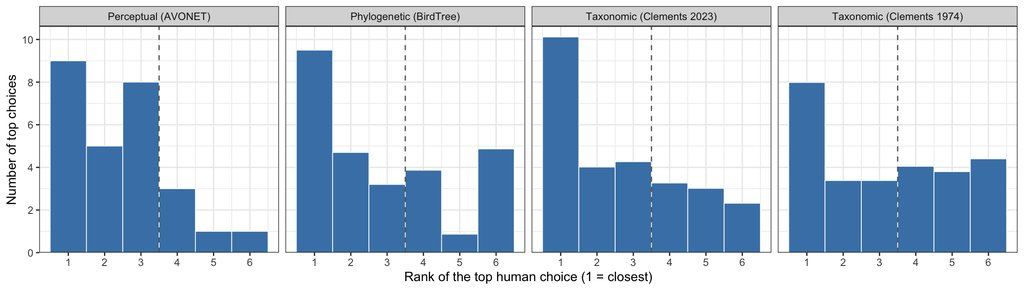

```r
# Ties are split over the ranks they span, so the bars sit on the integer ranks
# 1-6 and can hold fractional counts. The dashed line at 3.5 is the mean rank
# expected if a measure ordered the candidates at random.

rank_histograms <- ggplot(SplitTies(top_choice_ranks),
                          aes(x = Slot, weight = share)) +
  geom_histogram(binwidth = 1, boundary = 0.5,
                 fill = "steelblue", colour = "white", linewidth = 0.3) +
  geom_vline(xintercept = 3.5, linetype = "dashed", colour = "grey40") +
  facet_wrap(~ Measure, nrow = 1) +
  scale_x_continuous(breaks = 1:6) +
  scale_y_continuous(breaks = scales::breaks_width(2),
                     expand = expansion(mult = c(0, 0.05))) +
  # coord_cartesian rather than scale limits: setting limits on the x scale would
  # widen the binning range and then drop the empty edge bins with a warning
  coord_cartesian(xlim = c(0.5, 6.5)) +
  theme_bw() +
  labs(x = "Rank of the top human choice (1 = closest)",
       y = "Number of top choices")

rank_histograms
```

Mean rank of the top human choice under each measure. The mean of the tie-split distribution in the histograms is exactly the fractional rank, so these means are the same whichever way ties are handled.

```r
# Every top choice counts once, so the array-bootstrap weight is 1. The subject
# bootstrap recomputes which candidate is modal in each replicate.
top_choice_draws_arrays <- BootstrapMeanRankArrays(top_choice_ranks %>% mutate(w = 1))
top_choice_draws_subjects <- BootstrapMeanRankSubjects(
  all_choice_ranks_full, statistic = "top")

top_choice_base <- top_choice_ranks %>%
  group_by(Measure) %>%
  summarise(observations = n(),
            mean_rank = mean(Rank))
```

Resampling over arrays:

```r
top_choice_summary_arrays <- AddCi(top_choice_base, top_choice_draws_arrays)

top_choice_summary_arrays
```

| Measure | observations | mean_rank | ci_lower | ci_upper |
| --- | --- | --- | --- | --- |
| Perceptual (AVONET) | 27 | 2.44 | 1.93 | 2.96 |
| Phylogenetic (BirdTree) | 27 | 2.87 | 2.16 | 3.58 |
| Taxonomic (Clements 2023) | 27 | 2.70 | 2.25 | 3.13 |
| Taxonomic (Clements 1974) | 27 | 3.20 | 2.65 | 3.72 |

Resampling over subjects:

```r
top_choice_summary_subjects <- AddCi(top_choice_base, top_choice_draws_subjects)

top_choice_summary_subjects
```

| Measure | observations | mean_rank | ci_lower | ci_upper |
| --- | --- | --- | --- | --- |
| Perceptual (AVONET) | 27 | 2.44 | 2.15 | 2.70 |
| Phylogenetic (BirdTree) | 27 | 2.87 | 2.40 | 2.98 |
| Taxonomic (Clements 2023) | 27 | 2.70 | 2.44 | 2.79 |
| Taxonomic (Clements 1974) | 27 | 3.20 | 2.93 | 3.31 |

# Rank of every choice the subjects made

The histograms above throw away most of the data: each array contributes only its winning candidate, so a candidate chosen by 15 of the 34 subjects and one chosen by a single subject count the same.

These histograms use every choice instead. Each of the 156 candidates contributes its rank once per subject who chose it, so in array 1 the gray-cheeked thrush (15 subjects, and the closest bird on the perceptual measure) contributes fifteen 1s while the American robin (1 subject, ranked fourth) contributes a single 4. Candidates that nobody chose drop out. That gives 883 observations per measure - 34 subjects x 26 arrays, less the one response array 25 is missing in Brown’s printed table.

```r
all_choice_ranks <- brown_table3_similarity %>%
  filter(n > 0) %>%
  select(array, british_target, american_bird, n,
         all_of(measures$RankColumn)) %>%
  pivot_longer(cols = all_of(measures$RankColumn),
               names_to = "RankColumn",
               values_to = "Rank") %>%
  mutate(Measure = factor(measures$Measure[match(RankColumn, measures$RankColumn)],
                          levels = measures$Measure)) %>%
  select(-RankColumn)

stopifnot(
  all(all_choice_ranks %>%
        group_by(Measure) %>%
        summarise(subjects = sum(n)) %>%
        pull(subjects) == 883)
)
```

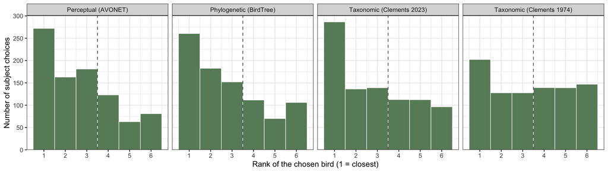

```r
# Same bins, tie splitting and chance line as the top-choice histograms, but each
# row is also weighted by the number of subjects who picked that candidate

all_choice_histograms <- ggplot(SplitTies(all_choice_ranks),
                                aes(x = Slot, weight = n * share)) +
  geom_histogram(binwidth = 1, boundary = 0.5,
                 fill = "darkseagreen4", colour = "white", linewidth = 0.3) +
  geom_vline(xintercept = 3.5, linetype = "dashed", colour = "grey40") +
  facet_wrap(~ Measure, nrow = 1) +
  scale_x_continuous(breaks = 1:6) +
  scale_y_continuous(breaks = scales::breaks_width(50),
                     expand = expansion(mult = c(0, 0.05))) +
  coord_cartesian(xlim = c(0.5, 6.5)) +
  theme_bw() +
  labs(x = "Rank of the chosen bird (1 = closest)",
       y = "Number of subject choices")

all_choice_histograms
```

Weighting by subject means these means are directly comparable with the top-choice table above, and 3.5 is again the value expected if a measure ordered the candidates at random.

```r
# Here each row carries the number of subjects who made that choice
all_choice_draws_arrays <- BootstrapMeanRankArrays(all_choice_ranks %>% mutate(w = n))
all_choice_draws_subjects <- BootstrapMeanRankSubjects(
  all_choice_ranks_full, statistic = "weighted")

all_choice_base <- all_choice_ranks %>%
  group_by(Measure) %>%
  summarise(choices = sum(n),
            mean_rank = weighted.mean(Rank, n))
```

Resampling over arrays:

```r
all_choice_summary_arrays <- AddCi(all_choice_base, all_choice_draws_arrays)

all_choice_summary_arrays
```

| Measure | choices | mean_rank | ci_lower | ci_upper |
| --- | --- | --- | --- | --- |
| Perceptual (AVONET) | 883 | 2.76 | 2.43 | 3.08 |
| Phylogenetic (BirdTree) | 883 | 2.85 | 2.48 | 3.22 |
| Taxonomic (Clements 2023) | 883 | 2.91 | 2.61 | 3.17 |
| Taxonomic (Clements 1974) | 883 | 3.37 | 3.01 | 3.72 |

Resampling over subjects:

```r
all_choice_summary_subjects <- AddCi(all_choice_base, all_choice_draws_subjects)

all_choice_summary_subjects
```

| Measure | choices | mean_rank | ci_lower | ci_upper |
| --- | --- | --- | --- | --- |
| Perceptual (AVONET) | 883 | 2.76 | 2.66 | 2.85 |
| Phylogenetic (BirdTree) | 883 | 2.85 | 2.76 | 2.94 |
| Taxonomic (Clements 2023) | 883 | 2.91 | 2.84 | 2.97 |
| Taxonomic (Clements 1974) | 883 | 3.37 | 3.31 | 3.43 |

The two tables carry the same mean ranks and differ only in the interval. The array intervals are several times wider, because there are only 26 arrays however many subjects sit inside them: 34 people judging the same six pictures pin down what humans think of *that array* very precisely, but supply only one piece of evidence about the measures.

# Comparing the measures

Each pair of measures, compared on the same bootstrap replicates - so the two are always scored on an identical draw of arrays, and the comparison is paired. `difference` is `Measure_A` minus `Measure_B`, so a negative value means A ranked the chosen birds closer than B did.

```r
# Unrounded means, so the reported differences are exact
top_choice_observed <- setNames(top_choice_base$mean_rank,
                                as.character(top_choice_base$Measure))
all_choice_observed <- setNames(all_choice_base$mean_rank,
                                as.character(all_choice_base$Measure))

RoundComparisons <- function(comparisons) {
  comparisons %>%
    mutate(across(c(difference, ci_lower, ci_upper), ~round(.x, 2)),
           p_value = round(p_value, 4))
}
```

## Top choice only

Resampling over arrays:

```r
top_choice_comparisons_arrays <-
  BootstrapCompare(top_choice_draws_arrays, top_choice_observed)

RoundComparisons(top_choice_comparisons_arrays)
```

| Measure_A | Measure_B | difference | ci_lower | ci_upper | p_value |
| --- | --- | --- | --- | --- | --- |
| Perceptual (AVONET) | Phylogenetic (BirdTree) | -0.43 | -1.19 | 0.37 | 0.3122 |
| Perceptual (AVONET) | Taxonomic (Clements 2023) | -0.26 | -0.85 | 0.37 | 0.4148 |
| Perceptual (AVONET) | Taxonomic (Clements 1974) | -0.76 | -1.46 | -0.02 | 0.0490 |
| Phylogenetic (BirdTree) | Taxonomic (Clements 2023) | 0.17 | -0.37 | 0.69 | 0.5733 |
| Phylogenetic (BirdTree) | Taxonomic (Clements 1974) | -0.33 | -1.02 | 0.32 | 0.3450 |
| Taxonomic (Clements 2023) | Taxonomic (Clements 1974) | -0.50 | -0.83 | -0.20 | 0.0008 |

Resampling over subjects:

```r
top_choice_comparisons_subjects <-
  BootstrapCompare(top_choice_draws_subjects, top_choice_observed)

RoundComparisons(top_choice_comparisons_subjects)
```

| Measure_A | Measure_B | difference | ci_lower | ci_upper | p_value |
| --- | --- | --- | --- | --- | --- |
| Perceptual (AVONET) | Phylogenetic (BirdTree) | -0.43 | -0.64 | 0.09 | 0.1254 |
| Perceptual (AVONET) | Taxonomic (Clements 2023) | -0.26 | -0.48 | 0.07 | 0.1450 |
| Perceptual (AVONET) | Taxonomic (Clements 1974) | -0.76 | -1.02 | -0.43 | 0.0002 |
| Phylogenetic (BirdTree) | Taxonomic (Clements 2023) | 0.17 | -0.13 | 0.29 | 0.4082 |
| Phylogenetic (BirdTree) | Taxonomic (Clements 1974) | -0.33 | -0.63 | -0.23 | 0.0002 |
| Taxonomic (Clements 2023) | Taxonomic (Clements 1974) | -0.50 | -0.58 | -0.40 | 0.0002 |

## All choices

Resampling over arrays:

```r
all_choice_comparisons_arrays <-
  BootstrapCompare(all_choice_draws_arrays, all_choice_observed)

RoundComparisons(all_choice_comparisons_arrays)
```

| Measure_A | Measure_B | difference | ci_lower | ci_upper | p_value |
| --- | --- | --- | --- | --- | --- |
| Perceptual (AVONET) | Phylogenetic (BirdTree) | -0.09 | -0.46 | 0.32 | 0.6431 |
| Perceptual (AVONET) | Taxonomic (Clements 2023) | -0.15 | -0.48 | 0.19 | 0.4046 |
| Perceptual (AVONET) | Taxonomic (Clements 1974) | -0.61 | -1.07 | -0.15 | 0.0090 |
| Phylogenetic (BirdTree) | Taxonomic (Clements 2023) | -0.06 | -0.37 | 0.23 | 0.7311 |
| Phylogenetic (BirdTree) | Taxonomic (Clements 1974) | -0.52 | -0.99 | -0.08 | 0.0176 |
| Taxonomic (Clements 2023) | Taxonomic (Clements 1974) | -0.46 | -0.73 | -0.22 | 0.0002 |

Resampling over subjects:

```r
all_choice_comparisons_subjects <-
  BootstrapCompare(all_choice_draws_subjects, all_choice_observed)

RoundComparisons(all_choice_comparisons_subjects)
```

| Measure_A | Measure_B | difference | ci_lower | ci_upper | p_value |
| --- | --- | --- | --- | --- | --- |
| Perceptual (AVONET) | Phylogenetic (BirdTree) | -0.09 | -0.21 | 0.03 | 0.1240 |
| Perceptual (AVONET) | Taxonomic (Clements 2023) | -0.15 | -0.24 | -0.06 | 0.0014 |
| Perceptual (AVONET) | Taxonomic (Clements 1974) | -0.61 | -0.71 | -0.51 | 0.0002 |
| Phylogenetic (BirdTree) | Taxonomic (Clements 2023) | -0.06 | -0.12 | 0.01 | 0.0908 |
| Phylogenetic (BirdTree) | Taxonomic (Clements 1974) | -0.52 | -0.59 | -0.45 | 0.0002 |
| Taxonomic (Clements 2023) | Taxonomic (Clements 1974) | -0.46 | -0.50 | -0.43 | 0.0002 |

The p values are uncorrected, and there are six comparisons in each block, so a single p just under 0.05 is not worth much on its own.

The two schemes disagree, and the disagreement is the point rather than a problem.

Resampling **over arrays**, only the gaps involving Clements 1974 come out clearly: perceptual, phylogenetic and Clements 2023 each beat it, and Clements 2023 beats it most decisively. The three leading measures cannot be separated from each other at all - perceptual against phylogenetic, perceptual against Clements 2023 and phylogenetic against Clements 2023 all have intervals straddling zero by a wide margin. On this reading the apparent ordering in the summary table is noise, and those three should not be put in any order.

Resampling **over subjects**, the same three gaps shrink their intervals by roughly a factor of four and perceptual against Clements 2023 becomes clearly non-zero, while perceptual against phylogenetic still does not. But this scheme holds the 26 arrays fixed, so it only says that *these particular arrays*, judged by other people, would keep giving that answer. It is not evidence that the ordering would survive a different set of birds.

Since the interesting claim is about naming in general rather than about Brown’s 26 stimulus sets, the array-resampled numbers are the ones to lean on, and they say the data are too thin to rank the three leading measures. The top-choice comparisons tell the same story more weakly again, as they should, using 27 observations rather than 883.

# Checks

Three pairs whose taxonomic distances can be worked out by hand. They also show why the 1974 and 2023 values differ, which is the point of carrying both.

```r
# spoonbill x roseate spoonbill
#   Dist23 = 1: Ajaia ajaja became Platalea ajaja, so in 2023 it shares the genus
#               Platalea with the British spoonbill (Platalea leucorodia)
#   Dist74 = 2: in 1974 it was still Ajaia, so same family, different genus
# blackbird x rusty blackbird
#   Dist23 = Dist74 = 3: Turdus merula (Turdidae) and Euphagus carolinus
#               (Icteridae) are different families but both Passeriformes
# great spotted woodpecker x downy woodpecker
#   Dist23 = 2: Dendrocopos major and Dryobates pubescens, both Picidae
#   Dist74 = 1: in 1974 the downy woodpecker was Dendrocopos pubescens, so the
#               two shared a genus

brown_table3_similarity %>%
  filter((british_target == "spoonbill" & american_bird == "roseate spoonbill") |
         (british_target == "blackbird" & american_bird == "rusty blackbird") |
         (british_target == "great spotted woodpecker" &
            american_bird == "downy woodpecker")) %>%
  select(british_target, american_bird, percent, DistPer, Dist23, Dist74)
```

| british_target | american_bird | percent | DistPer | Dist23 | Dist74 |
| --- | --- | --- | --- | --- | --- |
| blackbird | rusty blackbird | 35.3 | 0.9330454 | 3 | 3 |
| great spotted woodpecker | downy woodpecker | 44.1 | 2.7366427 | 2 | 1 |
| spoonbill | roseate spoonbill | 100.0 | 1.1442645 | 1 | 2 |

Array 24 is the one array where all 34 subjects agreed (spoonbill -> roseate spoonbill), so the roseate spoonbill should also be the perceptually closest of the six candidates.

```r
brown_table3_similarity %>%
  filter(array == 24) %>%
  select(american_bird, n, percent, DistPer, Dist23, Dist74) %>%
  arrange(DistPer)
```

| american_bird | n | percent | DistPer | Dist23 | Dist74 |
| --- | --- | --- | --- | --- | --- |
| roseate spoonbill | 34 | 100 | 1.144265 | 1 | 2 |
| white ibis | 0 | 0 | 2.102168 | 2 | 2 |
| glossy ibis | 0 | 0 | 2.524402 | 2 | 2 |
| American woodcock | 0 | 0 | 5.884452 | 4 | 4 |
| long-billed dowitcher | 0 | 0 | 6.303960 | 4 | 4 |
| common snipe | 0 | 0 | 6.645383 | 4 | 4 |

# Export

```r
# Without the BirdTree nexus the phylogenetic columns would be entirely NA, so
# drop them rather than export empty columns

drop_unused_phylo <- function(data) {
  if (have_phylo) data else select(data, -any_of(c("DistPhy", "zDistPhy")))
}

# The distances were kept at full precision for ranking; 2 dp is plenty on export
round_distances <- function(data) {
  mutate(data, across(any_of(c("DistPer", "DistPhy")), ~round(.x, 2)))
}

brown_bird_taxonomy <- brown_birds %>%
  select(BrownName, CommonNameBrown, NameSource,
         ScientificName2023, CommonName2023, Genus2023, Family2023, Order2023,
         ScientificName1974, Genus1974, Family1974, Order1974,
         ScientificName2021, ScientificNameV3,
         BeakLengthCulmen:Mass) %>%
  arrange(BrownName)

write.csv(brown_bird_taxonomy,
          here("brown_britishnames/brown_bird_taxonomy.csv"),
          row.names = FALSE)

write.csv(brown_pairs %>% drop_unused_phylo() %>% round_distances(),
          here("brown_britishnames/brown_similarity_pairs.csv"),
          row.names = FALSE)

write.csv(brown_table3_similarity %>% drop_unused_phylo() %>% round_distances(),
          here("brown_britishnames/brown_table3_similarity.csv"),
          row.names = FALSE)
```

# Perceptual similarity with colour

AVONET describes shape and size but says nothing about plumage, and Brown’s subjects were looking at coloured pictures. This section adds the colour data the pipeline uses and builds a perceptual measure from AVONET and colour together.

The colour data and its handling are copied from `preprocessing/Preprocessing.Rmd` (the “Colour Data” section, which follows Santangeli et al.). The six colour variables are black, white, yellow, blue, red and green; red, blue and green are the sums of their light and dark versions. Where a species has separate male and female rows, the more colourful one is kept. The pipeline’s colour distance is Euclidean distance on the six z-scored variables, with no log transform.

The pipeline never builds a single combined distance. The analyses (`analyses/Analyses.Rmd`) enter `zDistPer` and `zDistCol` side by side in logistic regressions predicting name sharing, and let the fit weight them. Brown’s data has nothing to fit, so two fixed weightings are tried:

```
DistPerCol  = z(DistPer) + z(DistCol)
DistPerColW = z(DistPer) + (0.38 / 3.70) z(DistCol)
```

The first gives the two equal weight. The second takes its weights from the regression pooled over all languages in `output/ResultsTableLR_col.tex` (Per+Col model: beta = -3.70 for perceptual, -0.38 for colour), so colour counts for about a tenth as much as AVONET. The per-language ratios range from about 2.6:1 (Saami) to 17:1 (Anindilyakwa).

Both are z-scored over the 546 within-array pairs, the same scaling as the `zDist` columns above. The regressions z-score over all pairs within a language instead, so the borrowed weights are an approximation. Colour on its own is reported as well, so the combined measures can be read against both of their parts.

## Load the colour data

```r
colour_data <- read.csv(here("preprocessing/data/colour_data.csv")) %>%
  rename(ScientificNameV3 = BirdTREE,
         ScientificName2021 = sciName_ebird2021,
         cDiversity = n.loci,
         cElaboration = elaboration,
         cBlack = black,
         cWhite = white,
         cYellow = yellow) %>%
  mutate(cRed = redD + redL,
         cBlue = blueD + blueL,
         cGreen = greenD + greenL) %>%
  filter(!is.na(cElaboration)) %>%
  arrange(desc(cElaboration)) %>%
  select(ScientificName2021,
         cBlack,
         cWhite,
         cYellow,
         cBlue,
         cRed,
         cGreen,
         cElaboration) %>%
  # Keep the most colourful set of observations for each bird
  distinct(ScientificName2021, .keep_all = TRUE)

# The pipeline falls back to the V3 name when the 2021 name finds nothing, and
# duplicates the Larus canus row for Larus brachyrhynchus. Neither is needed here:
# all 99 of Brown's birds match on their 2021 name.

brown_colours <- brown_birds %>%
  select(CanonicalName, ScientificName2021) %>%
  left_join(colour_data, by = "ScientificName2021", relationship = "one-to-one")

stopifnot(
  nrow(brown_colours) == 99,
  !any(is.na(brown_colours %>% select(cBlack:cGreen)))
)
```

## Colour and combined distances

```r
col_data <- brown_colours %>%
  select(CanonicalName, cBlack:cGreen) %>%
  mutate_if(is.numeric, ~scale(.)[,1])

# Make a matrix with euclidean distances between all birds based on their colours

col_matrix <- col_data %>%
  select(cBlack:cGreen) %>%
  data.matrix() %>%
  pdist(metric = "euclidean", p = 2) %>%
  as.data.frame()

rownames(col_matrix) <- col_data$CanonicalName
colnames(col_matrix) <- col_data$CanonicalName

col_dist_list <- data.frame(t(combn(names(col_matrix), 2)),
                            DistCol = t(col_matrix)[lower.tri(col_matrix)]) %>%
  mutate(Species1 = pmin(X1, X2),
         Species2 = pmax(X1, X2)) %>%
  select(Species1, Species2, DistCol)

# Colour coefficient relative to perceptual, from the pooled Per+Col logistic
# regression in analyses/Analyses.Rmd (output/ResultsTableLR_col.tex)
colour_weight <- 0.38 / 3.70

# Within-array pairs, with the combined distances. Rounded to 8 dp for ranking, as
# DistPer and DistPhy are above.

colour_pairs <- brown_pairs %>%
  select(array, Species1, Species2, DistPer) %>%
  left_join(col_dist_list, by = c("Species1", "Species2")) %>%
  mutate(DistPerCol = scale(DistPer)[,1] + scale(DistCol)[,1],
         DistPerColW = scale(DistPer)[,1] + colour_weight * scale(DistCol)[,1],
         DistCol = round(DistCol, 8),
         DistPerCol = round(DistPerCol, 8),
         DistPerColW = round(DistPerColW, 8)) %>%
  select(-DistPer)

stopifnot(
  nrow(colour_pairs) == 546,
  !any(is.na(colour_pairs$DistCol))
)

# How closely the two parts agree within arrays
cor(brown_pairs$DistPer, colour_pairs$DistCol)
```

```
## [1] 0.2060749
```

```r
brown_table3_colour <- brown_table3_similarity %>%
  mutate(Species1 = pmin(british_scientificname2023, american_scientificname2023),
         Species2 = pmax(british_scientificname2023, american_scientificname2023)) %>%
  left_join(colour_pairs, by = c("array", "Species1", "Species2")) %>%
  select(-Species1, -Species2)

stopifnot(
  nrow(brown_table3_colour) == 156,
  !any(is.na(brown_table3_colour$DistPerCol)),
  !any(is.na(brown_table3_colour$DistPerColW))
)
```

## Rank the candidates

The same ranking as before, now over seven measures. The four existing measures are re-ranked from the same distances, and a check confirms their ranks are unchanged.

```r
measures_col <- bind_rows(
  measures %>% slice(1),
  tribble(
    ~DistColumn,  ~RankColumn,  ~Measure,
    "DistCol",    "RankCol",    "Colour",
    "DistPerCol", "RankPerCol", "Perceptual + colour (equal)",
    "DistPerColW", "RankPerColW", "Perceptual + colour (weighted)"),
  measures %>% slice(-1)
)

col_ranks_full <- brown_table3_colour %>%
  select(array, american_bird, n, all_of(measures_col$DistColumn)) %>%
  pivot_longer(cols = all_of(measures_col$DistColumn),
               names_to = "DistColumn",
               values_to = "Dist") %>%
  group_by(array, DistColumn) %>%
  mutate(Rank = rank(Dist, ties.method = "average"),
         RankMin = rank(Dist, ties.method = "min"),
         RankMax = rank(Dist, ties.method = "max")) %>%
  ungroup() %>%
  mutate(Measure = factor(measures_col$Measure[match(DistColumn,
                                                     measures_col$DistColumn)],
                          levels = measures_col$Measure))

col_spans <- col_ranks_full %>%
  select(array, american_bird, Measure, RankMin, RankMax)

col_ranks_full <- col_ranks_full %>%
  select(array, american_bird, n, Measure, Rank)

# The existing measures must rank exactly as they did before
stopifnot(
  isTRUE(all.equal(
    col_ranks_full %>%
      filter(Measure %in% measures$Measure) %>%
      arrange(array, american_bird, Measure) %>%
      pull(Rank),
    all_choice_ranks_full %>%
      arrange(array, american_bird, Measure) %>%
      pull(Rank)))
)

col_top_ranks <- col_ranks_full %>%
  semi_join(top_choice, by = c("array", "american_bird"))

col_all_ranks <- col_ranks_full %>%
  filter(n > 0)

stopifnot(
  nrow(col_top_ranks) == 27 * nrow(measures_col),
  sum(col_all_ranks$n) == 883 * nrow(measures_col)
)
```

## Histograms

The same tie-split histograms as above, for all seven measures.

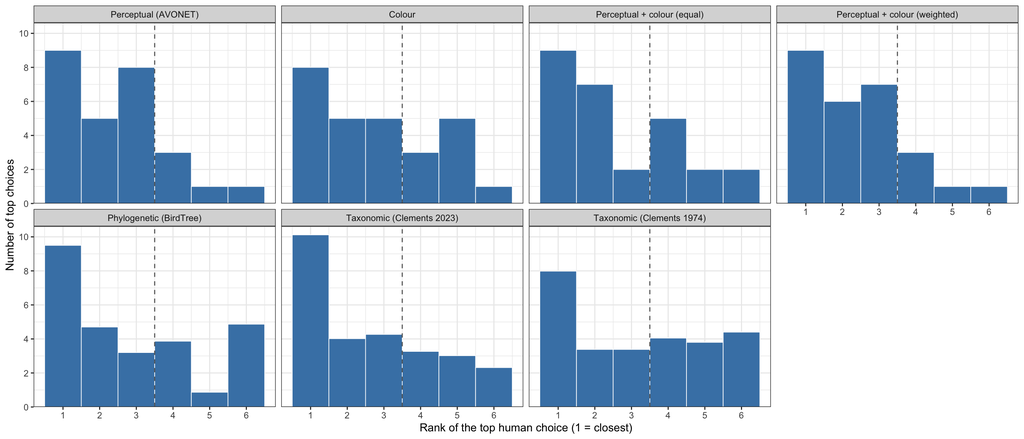

```r
col_top_histograms <- ggplot(SplitTies(col_top_ranks, col_spans),
                             aes(x = Slot, weight = share)) +
  geom_histogram(binwidth = 1, boundary = 0.5,
                 fill = "steelblue", colour = "white", linewidth = 0.3) +
  geom_vline(xintercept = 3.5, linetype = "dashed", colour = "grey40") +
  facet_wrap(~ Measure, ncol = 4) +
  scale_x_continuous(breaks = 1:6) +
  scale_y_continuous(breaks = scales::breaks_width(2),
                     expand = expansion(mult = c(0, 0.05))) +
  coord_cartesian(xlim = c(0.5, 6.5)) +
  theme_bw() +
  labs(x = "Rank of the top human choice (1 = closest)",
       y = "Number of top choices")

col_top_histograms
```

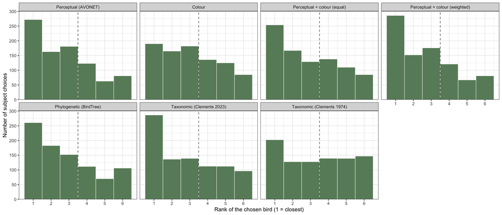

```r
col_all_histograms <- ggplot(SplitTies(col_all_ranks, col_spans),
                             aes(x = Slot, weight = n * share)) +
  geom_histogram(binwidth = 1, boundary = 0.5,
                 fill = "darkseagreen4", colour = "white", linewidth = 0.3) +
  geom_vline(xintercept = 3.5, linetype = "dashed", colour = "grey40") +
  facet_wrap(~ Measure, ncol = 4) +
  scale_x_continuous(breaks = 1:6) +
  scale_y_continuous(breaks = scales::breaks_width(50),
                     expand = expansion(mult = c(0, 0.05))) +
  coord_cartesian(xlim = c(0.5, 6.5)) +
  theme_bw() +
  labs(x = "Rank of the chosen bird (1 = closest)",
       y = "Number of subject choices")

col_all_histograms
```

## Mean rank

Mean rank of the chosen birds under all seven measures, with 95% intervals. The comparisons are restricted to the pairs that involve one of the three new measures. The rows for the four existing measures repeat the earlier tables apart from the bootstrap noise in their intervals.

```r
# Runs one resampling scheme. `weighted` is TRUE for all choices (each row weighted
# by its votes) and FALSE for the top choice only. Returns the summary table and the
# comparisons involving a new measure.

ColourScheme <- function(ranks, weighted, scheme = c("arrays", "subjects")) {

  scheme <- match.arg(scheme)
  ranks <- ranks %>% mutate(w = if (weighted) n else 1)

  if (scheme == "arrays") {
    draws <- BootstrapMeanRankArrays(ranks)
  } else {
    draws <- BootstrapMeanRankSubjects(col_ranks_full,
                                       if (weighted) "weighted" else "top")
  }

  base <- ranks %>%
    group_by(Measure) %>%
    summarise(mean_rank = sum(w * Rank) / sum(w))

  observed <- setNames(base$mean_rank, as.character(base$Measure))

  new_measures <- c("Colour", "Perceptual + colour (equal)",
                    "Perceptual + colour (weighted)")

  comparisons <- BootstrapCompare(draws, observed) %>%
    filter(Measure_A %in% new_measures | Measure_B %in% new_measures) %>%
    RoundComparisons()

  list(summary = AddCi(base, draws), comparisons = comparisons)
}
```

### Top choice only

Resampling over arrays:

```r
col_top_arrays <- ColourScheme(col_top_ranks, weighted = FALSE, scheme = "arrays")

col_top_arrays$summary
```

| Measure | mean_rank | ci_lower | ci_upper |
| --- | --- | --- | --- |
| Perceptual (AVONET) | 2.44 | 1.92 | 2.96 |
| Colour | 2.81 | 2.22 | 3.42 |
| Perceptual + colour (equal) | 2.63 | 2.00 | 3.27 |
| Perceptual + colour (weighted) | 2.41 | 1.89 | 2.93 |
| Phylogenetic (BirdTree) | 2.87 | 2.17 | 3.57 |
| Taxonomic (Clements 2023) | 2.70 | 2.25 | 3.14 |
| Taxonomic (Clements 1974) | 3.20 | 2.66 | 3.75 |

```r
col_top_arrays$comparisons
```

| Measure_A | Measure_B | difference | ci_lower | ci_upper | p_value |
| --- | --- | --- | --- | --- | --- |
| Perceptual (AVONET) | Colour | -0.37 | -1.12 | 0.37 | 0.3478 |
| Perceptual (AVONET) | Perceptual + colour (equal) | -0.19 | -0.81 | 0.46 | 0.5981 |
| Perceptual (AVONET) | Perceptual + colour (weighted) | 0.04 | -0.14 | 0.23 | 0.8997 |
| Colour | Perceptual + colour (equal) | 0.19 | -0.25 | 0.62 | 0.4538 |
| Colour | Perceptual + colour (weighted) | 0.41 | -0.28 | 1.11 | 0.2642 |
| Colour | Phylogenetic (BirdTree) | -0.06 | -0.87 | 0.79 | 0.9059 |
| Colour | Taxonomic (Clements 2023) | 0.11 | -0.54 | 0.80 | 0.7809 |
| Colour | Taxonomic (Clements 1974) | -0.39 | -1.07 | 0.29 | 0.2850 |
| Perceptual + colour (equal) | Perceptual + colour (weighted) | 0.22 | -0.35 | 0.78 | 0.4700 |
| Perceptual + colour (equal) | Phylogenetic (BirdTree) | -0.24 | -1.12 | 0.64 | 0.5987 |

[output cut: 5 more lines]

Resampling over subjects:

```r
col_top_subjects <- ColourScheme(col_top_ranks, weighted = FALSE, scheme = "subjects")

col_top_subjects$summary
```

| Measure | mean_rank | ci_lower | ci_upper |
| --- | --- | --- | --- |
| Perceptual (AVONET) | 2.44 | 2.15 | 2.70 |
| Colour | 2.81 | 2.62 | 3.15 |
| Perceptual + colour (equal) | 2.63 | 2.33 | 2.93 |
| Perceptual + colour (weighted) | 2.41 | 2.14 | 2.70 |
| Phylogenetic (BirdTree) | 2.87 | 2.41 | 2.98 |
| Taxonomic (Clements 2023) | 2.70 | 2.44 | 2.79 |
| Taxonomic (Clements 1974) | 3.20 | 2.93 | 3.31 |

```r
col_top_subjects$comparisons
```

| Measure_A | Measure_B | difference | ci_lower | ci_upper | p_value |
| --- | --- | --- | --- | --- | --- |
| Perceptual (AVONET) | Colour | -0.37 | -0.89 | -0.08 | 0.0196 |
| Perceptual (AVONET) | Perceptual + colour (equal) | -0.19 | -0.46 | 0.00 | 0.0808 |
| Perceptual (AVONET) | Perceptual + colour (weighted) | 0.04 | -0.07 | 0.11 | 0.9019 |
| Colour | Perceptual + colour (equal) | 0.19 | -0.04 | 0.56 | 0.1446 |
| Colour | Perceptual + colour (weighted) | 0.41 | 0.11 | 0.89 | 0.0114 |
| Colour | Phylogenetic (BirdTree) | -0.06 | -0.20 | 0.59 | 0.5487 |
| Colour | Taxonomic (Clements 2023) | 0.11 | -0.06 | 0.59 | 0.1358 |
| Colour | Taxonomic (Clements 1974) | -0.39 | -0.57 | 0.08 | 0.1394 |
| Perceptual + colour (equal) | Perceptual + colour (weighted) | 0.22 | 0.04 | 0.46 | 0.0240 |
| Perceptual + colour (equal) | Phylogenetic (BirdTree) | -0.24 | -0.46 | 0.32 | 0.5775 |

[output cut: 5 more lines]

### All choices

Resampling over arrays:

```r
col_all_arrays <- ColourScheme(col_all_ranks, weighted = TRUE, scheme = "arrays")

col_all_arrays$summary
```

| Measure | mean_rank | ci_lower | ci_upper |
| --- | --- | --- | --- |
| Perceptual (AVONET) | 2.76 | 2.43 | 3.08 |
| Colour | 3.11 | 2.78 | 3.43 |
| Perceptual + colour (equal) | 2.93 | 2.63 | 3.24 |
| Perceptual + colour (weighted) | 2.74 | 2.43 | 3.04 |
| Phylogenetic (BirdTree) | 2.85 | 2.48 | 3.22 |
| Taxonomic (Clements 2023) | 2.91 | 2.62 | 3.17 |
| Taxonomic (Clements 1974) | 3.37 | 3.02 | 3.72 |

```r
col_all_arrays$comparisons
```

| Measure_A | Measure_B | difference | ci_lower | ci_upper | p_value |
| --- | --- | --- | --- | --- | --- |
| Perceptual (AVONET) | Colour | -0.35 | -0.83 | 0.13 | 0.1460 |
| Perceptual (AVONET) | Perceptual + colour (equal) | -0.17 | -0.58 | 0.20 | 0.3856 |
| Perceptual (AVONET) | Perceptual + colour (weighted) | 0.01 | -0.08 | 0.13 | 0.8921 |
| Colour | Perceptual + colour (equal) | 0.18 | -0.08 | 0.42 | 0.1792 |
| Colour | Perceptual + colour (weighted) | 0.36 | -0.07 | 0.81 | 0.0978 |
| Colour | Phylogenetic (BirdTree) | 0.26 | -0.17 | 0.71 | 0.2594 |
| Colour | Taxonomic (Clements 2023) | 0.20 | -0.23 | 0.64 | 0.3780 |
| Colour | Taxonomic (Clements 1974) | -0.26 | -0.75 | 0.19 | 0.2740 |
| Perceptual + colour (equal) | Perceptual + colour (weighted) | 0.19 | -0.13 | 0.56 | 0.2988 |
| Perceptual + colour (equal) | Phylogenetic (BirdTree) | 0.08 | -0.36 | 0.57 | 0.7655 |

[output cut: 5 more lines]

Resampling over subjects:

```r
col_all_subjects <- ColourScheme(col_all_ranks, weighted = TRUE, scheme = "subjects")

col_all_subjects$summary
```

| Measure | mean_rank | ci_lower | ci_upper |
| --- | --- | --- | --- |
| Perceptual (AVONET) | 2.76 | 2.67 | 2.85 |
| Colour | 3.11 | 3.02 | 3.20 |
| Perceptual + colour (equal) | 2.93 | 2.83 | 3.03 |
| Perceptual + colour (weighted) | 2.74 | 2.65 | 2.84 |
| Phylogenetic (BirdTree) | 2.85 | 2.76 | 2.94 |
| Taxonomic (Clements 2023) | 2.91 | 2.84 | 2.97 |
| Taxonomic (Clements 1974) | 3.37 | 3.31 | 3.43 |

```r
col_all_subjects$comparisons
```

| Measure_A | Measure_B | difference | ci_lower | ci_upper | p_value |
| --- | --- | --- | --- | --- | --- |
| Perceptual (AVONET) | Colour | -0.35 | -0.48 | -0.23 | 0.0002 |
| Perceptual (AVONET) | Perceptual + colour (equal) | -0.17 | -0.25 | -0.09 | 0.0002 |
| Perceptual (AVONET) | Perceptual + colour (weighted) | 0.01 | -0.02 | 0.04 | 0.4488 |
| Colour | Perceptual + colour (equal) | 0.18 | 0.09 | 0.26 | 0.0002 |
| Colour | Perceptual + colour (weighted) | 0.36 | 0.25 | 0.48 | 0.0002 |
| Colour | Phylogenetic (BirdTree) | 0.26 | 0.14 | 0.38 | 0.0002 |
| Colour | Taxonomic (Clements 2023) | 0.20 | 0.10 | 0.30 | 0.0004 |
| Colour | Taxonomic (Clements 1974) | -0.26 | -0.36 | -0.16 | 0.0002 |
| Perceptual + colour (equal) | Perceptual + colour (weighted) | 0.19 | 0.12 | 0.25 | 0.0002 |
| Perceptual + colour (equal) | Phylogenetic (BirdTree) | 0.08 | -0.05 | 0.21 | 0.2268 |

[output cut: 5 more lines]

Adding colour at equal weight does not help. Over all choices, colour on its own has a mean rank of 3.11. That is better than Clements 1974 (3.37) but behind AVONET (2.76), phylogenetic (2.85) and Clements 2023 (2.91). The equal-weight combination lands between its two parts, at 2.93 over all choices and 2.63 for the top choice, so giving colour as much weight as AVONET pulls AVONET towards the weaker of the two. Within arrays the two distances are only weakly correlated (r = 0.21), so colour is not just repeating what AVONET already says.

With the weights from the language data, where colour counts about a tenth as much, the combination does marginally better than AVONET alone: 2.74 against 2.76 over all choices, and 2.41 against 2.44 for the top choice. These are the lowest mean ranks of any measure, but the gain over AVONET is tiny and not distinguishable from zero under either resampling scheme. Colour still matters at that weight: it changes the rank of 31 of the 156 candidates, in 12 of the 26 arrays (the equal-weight combination changes 97, in 24 arrays). The reorderings just help and hurt about equally.

As before, resampling over arrays separates little. The only clear gaps involving a new measure are that the weighted combination beats Clements 1974, on both the top choice and all choices. Resampling over subjects:

- AVONET beats colour alone, for both the top choice and all choices.
- The weighted combination beats the equal-weight one for both, and beats colour alone for both.
- On all choices, AVONET beats the equal-weight combination, and the weighted combination beats Clements 2023.
- Both combinations beat Clements 1974, for both the top choice and all choices.
- Colour alone falls behind AVONET, phylogenetic and Clements 2023 but beats Clements 1974.

Two caveats. Neither weighting is fitted to Brown’s data: equal weighting is arbitrary, and the regression weights come from a different task (sharing a folk name) on a different scale (z-scored within a language). And the six colour scores are coarse proportions of plumage area, which say nothing about where on the bird a colour sits - often what makes two pictures look alike.